# Sales Analytics

Analyze product sales performance by examining the types of products sold and the quantity sold over a given period.

## Problem Statement

Companies produce vast amounts of sales data for various items, places, and time periods. However, it becomes challenging to determine which goods are generating income, recognize seasonal trends, and comprehend consumer purchase behavior in the absence of comprehensive analysis. Missed opportunities, ineffective inventory management, and poor decision-making can result from this lack of understanding. By looking at product categories, sales volumes, and revenue patterns, this research seeks to assess sales success. The study will enable data-driven initiatives to boost business development, optimize product offerings, and improve decision-making by identifying trends and key drivers of sales.

## Key Analytical Questions

- Data Import, Cleaning, and Preparation
- Which is the best month for Sale?
- Which City has the maximum Orders?
- What Product sold the most & why?
- Understanding the trend of the most sold Product
- Which Products are most often sold together?

## Data Import, Cleaning, and Preparation

```python
#Import Library
import pandas as pd
import seaborn as sns
import numpy as np
import matplotlib.pyplot as plt
```

## PyArrow

PyArrow is a Python library commonly used to read and write the **Feather file format**. Feather is a fast, lightweight, and efficient binary file format for storing tabular data. It provides very high input/output (I/O) speed, requires minimal disk space, and allows data to be loaded directly into memory without unpacking. This makes it ideal for handling large datasets quickly during analytics workflows.

```python
!pip install pyarrow
```

```python
#Load the Dataset
all_data = pd.read_feather(r'D:\Resume Projects\Python\Sales_data.ftr')
```

```python
all_data.head(5)
```

|  | Order ID | Product | Quantity Ordered | Price Each | Order Date | Purchase Address |
| --- | --- | --- | --- | --- | --- | --- |
| 0 | 176558 | USB-C Charging Cable | 2 | 11.95 | 04/19/19 08:46 | 917 1st St, Dallas, TX 75001 |
| 1 | None | None | None | None | None | None |
| 2 | 176559 | Bose SoundSport Headphones | 1 | 99.99 | 04/07/19 22:30 | 682 Chestnut St, Boston, MA 02215 |
| 3 | 176560 | Google Phone | 1 | 600 | 04/12/19 14:38 | 669 Spruce St, Los Angeles, CA 90001 |
| 4 | 176560 | Wired Headphones | 1 | 11.99 | 04/12/19 14:38 | 669 Spruce St, Los Angeles, CA 90001 |

### Data Cleaning & Formating

```python
all_data.isnull().sum() ## checking out total missing values we have
```

```
Order ID            545
Product             545
Quantity Ordered    545
Price Each          545
Order Date          545
Purchase Address    545
dtype: int64
```

```python
### since there 545 observations where entire row have missing value , u can drop these 545 rows..
all_data = all_data.dropna(how = "all")
```

```python
all_data.isnull().sum()
```

```
Order ID            0
Product             0
Quantity Ordered    0
Price Each          0
Order Date          0
Purchase Address    0
dtype: int64
```

```python
all_data.duplicated()
```

```
0         False
2         False
3         False
4         False
5         False
          ...
186845    False
186846    False
186847    False
186848    False
186849    False
Length: 186305, dtype: bool
```

```python
all_data[all_data.duplicated()] ## total 618 duplicate rows ..
```

|  | Order ID | Product | Quantity Ordered | Price Each | Order Date | Purchase Address |
| --- | --- | --- | --- | --- | --- | --- |
| 31 | 176585 | Bose SoundSport Headphones | 1 | 99.99 | 04/07/19 11:31 | 823 Highland St, Boston, MA 02215 |
| 1149 | Order ID | Product | Quantity Ordered | Price Each | Order Date | Purchase Address |
| 1155 | Order ID | Product | Quantity Ordered | Price Each | Order Date | Purchase Address |
| 1302 | 177795 | Apple Airpods Headphones | 1 | 150 | 04/27/19 19:45 | 740 14th St, Seattle, WA 98101 |
| 1684 | 178158 | USB-C Charging Cable | 1 | 11.95 | 04/28/19 21:13 | 197 Center St, San Francisco, CA 94016 |
| ... | ... | ... | ... | ... | ... | ... |
| 186563 | Order ID | Product | Quantity Ordered | Price Each | Order Date | Purchase Address |
| 186632 | Order ID | Product | Quantity Ordered | Price Each | Order Date | Purchase Address |
| 186738 | Order ID | Product | Quantity Ordered | Price Each | Order Date | Purchase Address |
| 186782 | 259296 | Apple Airpods Headphones | 1 | 150 | 09/28/19 16:48 | 894 6th St, Dallas, TX 75001 |
| 186785 | 259297 | Lightning Charging Cable | 1 | 14.95 | 09/15/19 18:54 | 138 Main St, Boston, MA 02215 |

618 rows × 6 columns

```python
all_data = all_data.drop_duplicates() ## Dropping all the duplicate rows ..
```

```python
all_data.shape
```

```
(185687, 6)
```

```python
all_data[all_data.duplicated()]
```

|  | Order ID | Product | Quantity Ordered | Price Each | Order Date | Purchase Address |
| --- | --- | --- | --- | --- | --- | --- |

```python
## Tha Data has been cleaned ##
```

## Which is the best month for sale?

```python
all_data.head(2)
```

|  | Order ID | Product | Quantity Ordered | Price Each | Order Date | Purchase Address |
| --- | --- | --- | --- | --- | --- | --- |
| 0 | 176558 | USB-C Charging Cable | 2 | 11.95 | 04/19/19 08:46 | 917 1st St, Dallas, TX 75001 |
| 2 | 176559 | Bose SoundSport Headphones | 1 | 99.99 | 04/07/19 22:30 | 682 Chestnut St, Boston, MA 02215 |

```python
all_data['Order Date'][0].split('/')[0]
```

```
'04'
```

```python
def return_month(x):
    return x.split('/')[0]
```

```python
all_data['Month'] = all_data['Order Date'].apply(return_month)
```

```python
all_data.dtypes
```

```
Order ID            object
Product             object
Quantity Ordered    object
Price Each          object
Order Date          object
Purchase Address    object
Month               object
dtype: object
```

```python
all_data['Month'].unique() ## checking unique months
```

```
array(['04', '05', 'Order Date', '08', '09', '12', '01', '02', '03', '07',
       '06', '11', '10'], dtype=object)
```

```python
filter1 = all_data['Month'] == 'Order Date'
```

```python
all_data[~filter1]
```

|  | Order ID | Product | Quantity Ordered | Price Each | Order Date | Purchase Address | Month |
| --- | --- | --- | --- | --- | --- | --- | --- |
| 0 | 176558 | USB-C Charging Cable | 2 | 11.95 | 04/19/19 08:46 | 917 1st St, Dallas, TX 75001 | 04 |
| 2 | 176559 | Bose SoundSport Headphones | 1 | 99.99 | 04/07/19 22:30 | 682 Chestnut St, Boston, MA 02215 | 04 |
| 3 | 176560 | Google Phone | 1 | 600 | 04/12/19 14:38 | 669 Spruce St, Los Angeles, CA 90001 | 04 |
| 4 | 176560 | Wired Headphones | 1 | 11.99 | 04/12/19 14:38 | 669 Spruce St, Los Angeles, CA 90001 | 04 |
| 5 | 176561 | Wired Headphones | 1 | 11.99 | 04/30/19 09:27 | 333 8th St, Los Angeles, CA 90001 | 04 |
| ... | ... | ... | ... | ... | ... | ... | ... |
| 186845 | 259353 | AAA Batteries (4-pack) | 3 | 2.99 | 09/17/19 20:56 | 840 Highland St, Los Angeles, CA 90001 | 09 |
| 186846 | 259354 | iPhone | 1 | 700 | 09/01/19 16:00 | 216 Dogwood St, San Francisco, CA 94016 | 09 |
| 186847 | 259355 | iPhone | 1 | 700 | 09/23/19 07:39 | 220 12th St, San Francisco, CA 94016 | 09 |
| 186848 | 259356 | 34in Ultrawide Monitor | 1 | 379.99 | 09/19/19 17:30 | 511 Forest St, San Francisco, CA 94016 | 09 |
| 186849 | 259357 | USB-C Charging Cable | 1 | 11.95 | 09/30/19 00:18 | 250 Meadow St, San Francisco, CA 94016 | 09 |

185686 rows × 7 columns

```python
all_data = all_data[~filter1] ## excluding all those rows which have entry as "Order Date" in month feature ..
```

```python
all_data.shape
```

```
(185686, 7)
```

```python
## use warnings package to get rid of any warnings ..
import warnings
from warnings import filterwarnings
filterwarnings('ignore')
```

```python
all_data['Month'] = all_data['Month'].astype(int)
```

```python
all_data.dtypes
```

```
Order ID            object
Product             object
Quantity Ordered    object
Price Each          object
Order Date          object
Purchase Address    object
Month                int32
dtype: object
```

```python
all_data['Quantity Ordered'] = all_data['Quantity Ordered'].astype(int)
all_data['Price Each'] = all_data['Price Each'].astype(float)
```

```python
all_data.dtypes
```

```
Order ID             object
Product              object
Quantity Ordered      int32
Price Each          float64
Order Date           object
Purchase Address     object
Month                 int32
dtype: object
```

```python
all_data['sales'] = all_data['Quantity Ordered'] * all_data['Price Each'] ## creating sales feature
```

```python
all_data['sales']
```

```
0          23.90
2          99.99
3         600.00
4          11.99
5          11.99
           ...
186845      8.97
186846    700.00
186847    700.00
186848    379.99
186849     11.95
Name: sales, Length: 185686, dtype: float64
```

```python
all_data.groupby(['Month'])['sales'].sum()
```

```
Month
1     1821413.16
2     2200078.08
3     2804973.35
4     3389217.98
5     3150616.23
6     2576280.15
7     2646461.32
8     2241083.37
9     2094465.69
10    3734777.86
11    3197875.05
12    4608295.70
Name: sales, dtype: float64
```

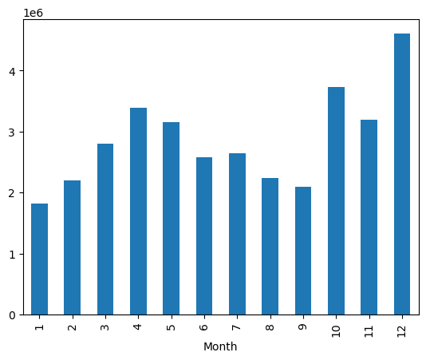

```python
all_data.groupby(['Month'])['sales'].sum().plot(kind='bar')
```

## Which city has Max Order

```python
all_data.head(2)
```

|  | Order ID | Product | Quantity Ordered | Price Each | Order Date | Purchase Address | Month | sales |
| --- | --- | --- | --- | --- | --- | --- | --- | --- |
| 0 | 176558 | USB-C Charging Cable | 2 | 11.95 | 04/19/19 08:46 | 917 1st St, Dallas, TX 75001 | 4 | 23.90 |
| 2 | 176559 | Bose SoundSport Headphones | 1 | 99.99 | 04/07/19 22:30 | 682 Chestnut St, Boston, MA 02215 | 4 | 99.99 |

```python
all_data['Purchase Address'][0]
```

```
'917 1st St, Dallas, TX 75001'
```

```python
all_data['city'] = all_data['Purchase Address'].str.split(',').str.get(1)
```

```python
all_data['city']
```

```
0                 Dallas
2                 Boston
3            Los Angeles
4            Los Angeles
5            Los Angeles
               ...
186845       Los Angeles
186846     San Francisco
186847     San Francisco
186848     San Francisco
186849     San Francisco
Name: city, Length: 185686, dtype: object
```

```python
pd.value_counts(all_data['city'])
```

```
city
San Francisco    44662
Los Angeles      29564
New York City    24847
Boston           19901
Atlanta          14863
Dallas           14797
Seattle          14713
Portland         12449
Austin            9890
Name: count, dtype: int64
```

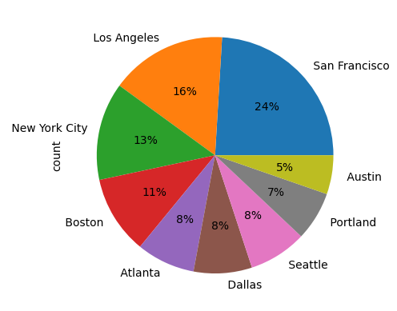

```python
pd.value_counts(all_data['city']).plot(kind='pie' , autopct = '%1.0f%%')
```

#### From this we can obtain our observation that San Francisco, Los Angeles, & New York City have contributed more than 50% of total orders

## What Product sold the most & why?

```python
all_data.columns
```

```
Index(['Order ID', 'Product', 'Quantity Ordered', 'Price Each', 'Order Date',
       'Purchase Address', 'Month', 'sales', 'city'],
      dtype='object')
```

```python
count_df = all_data.groupby(['Product']).agg({'Quantity Ordered':'sum' , 'Price Each':'mean'})
```

```python
count_df = count_df.reset_index()
```

```python
count_df
```

|  | Product | Quantity Ordered | Price Each |
| --- | --- | --- | --- |
| 0 | 20in Monitor | 4126 | 109.99 |
| 1 | 27in 4K Gaming Monitor | 6239 | 389.99 |
| 2 | 27in FHD Monitor | 7541 | 149.99 |
| 3 | 34in Ultrawide Monitor | 6192 | 379.99 |
| 4 | AA Batteries (4-pack) | 27615 | 3.84 |
| 5 | AAA Batteries (4-pack) | 30986 | 2.99 |
| 6 | Apple Airpods Headphones | 15637 | 150.00 |
| 7 | Bose SoundSport Headphones | 13430 | 99.99 |
| 8 | Flatscreen TV | 4813 | 300.00 |
| 9 | Google Phone | 5529 | 600.00 |
| 10 | LG Dryer | 646 | 600.00 |
| 11 | LG Washing Machine | 666 | 600.00 |
| 12 | Lightning Charging Cable | 23169 | 14.95 |
| 13 | Macbook Pro Laptop | 4725 | 1700.00 |
| 14 | ThinkPad Laptop | 4128 | 999.99 |
| 15 | USB-C Charging Cable | 23931 | 11.95 |
| 16 | Vareebadd Phone | 2068 | 400.00 |
| 17 | Wired Headphones | 20524 | 11.99 |
| 18 | iPhone | 6847 | 700.00 |

```python
products = count_df['Product'].values
```

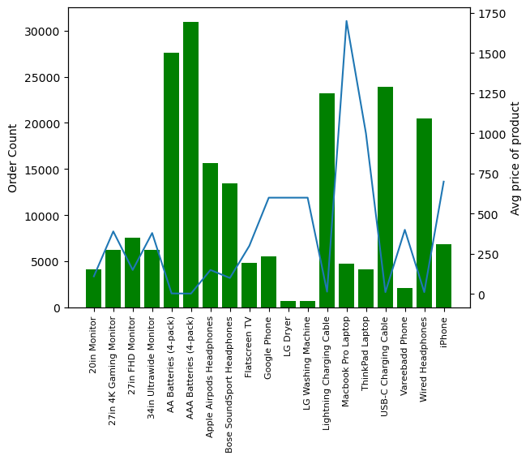

```python
fig , ax1 = plt.subplots()

ax2 = ax1.twinx() ## as X-axis is same for both plots , ie we are sharing x-axis , ie we have to use ax2 = ax1.twinx()

ax1.bar(count_df['Product'] , count_df['Quantity Ordered'] , color='g')
ax2.plot(count_df['Product'] , count_df['Price Each'] )
ax1.set_xticklabels(products , rotation='vertical' , fontsize=8 )

ax1.set_ylabel('Order Count')
ax2.set_ylabel('Avg price of product')
```

#### Insights : The top selling product is 'AAA Batteries'. The top selling products seems to have a correlation with the price of the product. The cheaper the product higher the quantity ordered and vice versa.

## Understanding Trend of the most sold Product

```python
all_data['Product'].value_counts()[0:5].index ## Top 5 most sold products ..
```

```
Index(['USB-C Charging Cable', 'Lightning Charging Cable',
       'AAA Batteries (4-pack)', 'AA Batteries (4-pack)', 'Wired Headphones'],
      dtype='object', name='Product')
```

```python
most_sold_product = all_data['Product'].value_counts()[0:5].index
```

```python
all_data['Product'].isin(most_sold_product)
```

```
0          True
2         False
3         False
4          True
5          True
          ...
186845     True
186846    False
186847    False
186848    False
186849     True
Name: Product, Length: 185686, dtype: bool
```

```python
most_sold_product_df = all_data[all_data['Product'].isin(most_sold_product)] ## data of Top 5 most sold products only ..
```

```python
most_sold_product_df.head(4)
```

|  | Order ID | Product | Quantity Ordered | Price Each | Order Date | Purchase Address | Month | sales | city |
| --- | --- | --- | --- | --- | --- | --- | --- | --- | --- |
| 0 | 176558 | USB-C Charging Cable | 2 | 11.95 | 04/19/19 08:46 | 917 1st St, Dallas, TX 75001 | 4 | 23.90 | Dallas |
| 4 | 176560 | Wired Headphones | 1 | 11.99 | 04/12/19 14:38 | 669 Spruce St, Los Angeles, CA 90001 | 4 | 11.99 | Los Angeles |
| 5 | 176561 | Wired Headphones | 1 | 11.99 | 04/30/19 09:27 | 333 8th St, Los Angeles, CA 90001 | 4 | 11.99 | Los Angeles |
| 6 | 176562 | USB-C Charging Cable | 1 | 11.95 | 04/29/19 13:03 | 381 Wilson St, San Francisco, CA 94016 | 4 | 11.95 | San Francisco |

```python
most_sold_product_df.groupby(['Month' , 'Product']).size()
```

```
Month  Product
1      AA Batteries (4-pack)       1037
       AAA Batteries (4-pack)      1084
       Lightning Charging Cable    1069
       USB-C Charging Cable        1171
       Wired Headphones            1004
2      AA Batteries (4-pack)       1274
       AAA Batteries (4-pack)      1320
       Lightning Charging Cable    1393
       USB-C Charging Cable        1511
       Wired Headphones            1179
3      AA Batteries (4-pack)       1672
       AAA Batteries (4-pack)      1645
       Lightning Charging Cable    1749
       USB-C Charging Cable        1766
       Wired Headphones            1512
4      AA Batteries (4-pack)       2062
       AAA Batteries (4-pack)      1988
       Lightning Charging Cable    2197
       USB-C Charging Cable        2074
       Wired Headphones            1888
5      AA Batteries (4-pack)       1821
       AAA Batteries (4-pack)      1888
       Lightning Charging Cable    1929
       USB-C Charging Cable        1879
       Wired Headphones            1729
6      AA Batteries (4-pack)       1540
       AAA Batteries (4-pack)      1451
       Lightning Charging Cable    1560
       USB-C Charging Cable        1531
       Wired Headphones            1334
7      AA Batteries (4-pack)       1555
       AAA Batteries (4-pack)      1554
       Lightning Charging Cable    1690
       USB-C Charging Cable        1667
       Wired Headphones            1434
8      AA Batteries (4-pack)       1357
       AAA Batteries (4-pack)      1340
       Lightning Charging Cable    1354
       USB-C Charging Cable        1339
       Wired Headphones            1191
9      AA Batteries (4-pack)       1314
       AAA Batteries (4-pack)      1281
       Lightning Charging Cable    1324
       USB-C Charging Cable        1451
       Wired Headphones            1173
10     AA Batteries (4-pack)       2240
       AAA Batteries (4-pack)      2234
       Lightning Charging Cable    2414
       USB-C Charging Cable        2437
       Wired Headphones            2091
11     AA Batteries (4-pack)       1970
       AAA Batteries (4-pack)      1999
       Lightning Charging Cable    2044
       USB-C Charging Cable        2054
       Wired Headphones            1777
12     AA Batteries (4-pack)       2716
       AAA Batteries (4-pack)      2828
       Lightning Charging Cable    2887
       USB-C Charging Cable        2979
       Wired Headphones            2537
dtype: int64
```

```python
pivot = most_sold_product_df.groupby(['Month' , 'Product']).size().unstack()
```

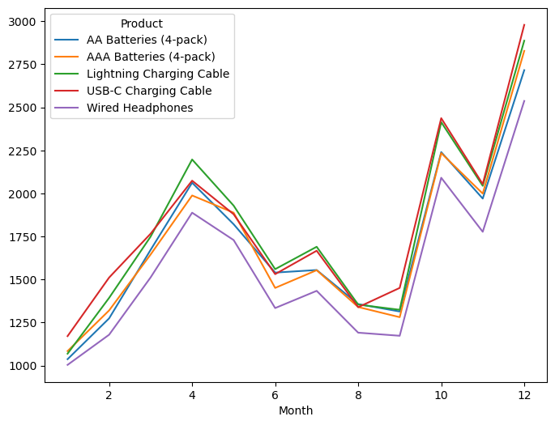

```python
pivot.plot(figsize=(8,6))
```

#### Inference : Products have been sold more in Oct , Nov , Dec

## 6.What products are most often sold together?

```python
all_data.columns
```

```
Index(['Order ID', 'Product', 'Quantity Ordered', 'Price Each', 'Order Date',
       'Purchase Address', 'Month', 'sales', 'city'],
      dtype='object')
```

```python
all_data['Order ID']
```

```
0         176558
2         176559
3         176560
4         176560
5         176561
           ...
186845    259353
186846    259354
186847    259355
186848    259356
186849    259357
Name: Order ID, Length: 185686, dtype: object
```

```python
df_duplicated = all_data[all_data['Order ID'].duplicated(keep=False)]
```

```python
df_duplicated ## dataframe in which we have those Order Ids who have purchased more products !
```

|  | Order ID | Product | Quantity Ordered | Price Each | Order Date | Purchase Address | Month | sales | city |
| --- | --- | --- | --- | --- | --- | --- | --- | --- | --- |
| 3 | 176560 | Google Phone | 1 | 600.00 | 04/12/19 14:38 | 669 Spruce St, Los Angeles, CA 90001 | 4 | 600.00 | Los Angeles |
| 4 | 176560 | Wired Headphones | 1 | 11.99 | 04/12/19 14:38 | 669 Spruce St, Los Angeles, CA 90001 | 4 | 11.99 | Los Angeles |
| 18 | 176574 | Google Phone | 1 | 600.00 | 04/03/19 19:42 | 20 Hill St, Los Angeles, CA 90001 | 4 | 600.00 | Los Angeles |
| 19 | 176574 | USB-C Charging Cable | 1 | 11.95 | 04/03/19 19:42 | 20 Hill St, Los Angeles, CA 90001 | 4 | 11.95 | Los Angeles |
| 32 | 176586 | AAA Batteries (4-pack) | 2 | 2.99 | 04/10/19 17:00 | 365 Center St, San Francisco, CA 94016 | 4 | 5.98 | San Francisco |
| ... | ... | ... | ... | ... | ... | ... | ... | ... | ... |
| 186792 | 259303 | AA Batteries (4-pack) | 1 | 3.84 | 09/20/19 20:18 | 106 7th St, Atlanta, GA 30301 | 9 | 3.84 | Atlanta |
| 186803 | 259314 | Wired Headphones | 1 | 11.99 | 09/16/19 00:25 | 241 Highland St, Atlanta, GA 30301 | 9 | 11.99 | Atlanta |
| 186804 | 259314 | AAA Batteries (4-pack) | 2 | 2.99 | 09/16/19 00:25 | 241 Highland St, Atlanta, GA 30301 | 9 | 5.98 | Atlanta |
| 186841 | 259350 | Google Phone | 1 | 600.00 | 09/30/19 13:49 | 519 Maple St, San Francisco, CA 94016 | 9 | 600.00 | San Francisco |
| 186842 | 259350 | USB-C Charging Cable | 1 | 11.95 | 09/30/19 13:49 | 519 Maple St, San Francisco, CA 94016 | 9 | 11.95 | San Francisco |

14128 rows × 9 columns

```python
dup_products = df_duplicated.groupby(['Order ID'])['Product'].apply(lambda x : ','.join(x)).reset_index().rename(columns={'Product':'grouped_products'})
```

```python
dup_products
```

|  | Order ID | grouped_products |
| --- | --- | --- |
| 0 | 141275 | USB-C Charging Cable,Wired Headphones |
| 1 | 141290 | Apple Airpods Headphones,AA Batteries (4-pack) |
| 2 | 141365 | Vareebadd Phone,Wired Headphones |
| 3 | 141384 | Google Phone,USB-C Charging Cable |
| 4 | 141450 | Google Phone,Bose SoundSport Headphones |
| ... | ... | ... |
| 6874 | 319536 | Macbook Pro Laptop,Wired Headphones |
| 6875 | 319556 | Google Phone,Wired Headphones |
| 6876 | 319584 | iPhone,Wired Headphones |
| 6877 | 319596 | iPhone,Lightning Charging Cable |
| 6878 | 319631 | 34in Ultrawide Monitor,Lightning Charging Cable |

6879 rows × 2 columns

```python
dup_products_df = df_duplicated.merge(dup_products , how='left' , on='Order ID')
```

```python
dup_products_df
```

|  | Order ID | Product | Quantity Ordered | Price Each | Order Date | Purchase Address | Month | sales | city | grouped_products |
| --- | --- | --- | --- | --- | --- | --- | --- | --- | --- | --- |
| 0 | 176560 | Google Phone | 1 | 600.00 | 04/12/19 14:38 | 669 Spruce St, Los Angeles, CA 90001 | 4 | 600.00 | Los Angeles | Google Phone,Wired Headphones |
| 1 | 176560 | Wired Headphones | 1 | 11.99 | 04/12/19 14:38 | 669 Spruce St, Los Angeles, CA 90001 | 4 | 11.99 | Los Angeles | Google Phone,Wired Headphones |
| 2 | 176574 | Google Phone | 1 | 600.00 | 04/03/19 19:42 | 20 Hill St, Los Angeles, CA 90001 | 4 | 600.00 | Los Angeles | Google Phone,USB-C Charging Cable |
| 3 | 176574 | USB-C Charging Cable | 1 | 11.95 | 04/03/19 19:42 | 20 Hill St, Los Angeles, CA 90001 | 4 | 11.95 | Los Angeles | Google Phone,USB-C Charging Cable |
| 4 | 176586 | AAA Batteries (4-pack) | 2 | 2.99 | 04/10/19 17:00 | 365 Center St, San Francisco, CA 94016 | 4 | 5.98 | San Francisco | AAA Batteries (4-pack),Google Phone |
| ... | ... | ... | ... | ... | ... | ... | ... | ... | ... | ... |
| 14123 | 259303 | AA Batteries (4-pack) | 1 | 3.84 | 09/20/19 20:18 | 106 7th St, Atlanta, GA 30301 | 9 | 3.84 | Atlanta | 34in Ultrawide Monitor,AA Batteries (4-pack) |
| 14124 | 259314 | Wired Headphones | 1 | 11.99 | 09/16/19 00:25 | 241 Highland St, Atlanta, GA 30301 | 9 | 11.99 | Atlanta | Wired Headphones,AAA Batteries (4-pack) |
| 14125 | 259314 | AAA Batteries (4-pack) | 2 | 2.99 | 09/16/19 00:25 | 241 Highland St, Atlanta, GA 30301 | 9 | 5.98 | Atlanta | Wired Headphones,AAA Batteries (4-pack) |
| 14126 | 259350 | Google Phone | 1 | 600.00 | 09/30/19 13:49 | 519 Maple St, San Francisco, CA 94016 | 9 | 600.00 | San Francisco | Google Phone,USB-C Charging Cable |
| 14127 | 259350 | USB-C Charging Cable | 1 | 11.95 | 09/30/19 13:49 | 519 Maple St, San Francisco, CA 94016 | 9 | 11.95 | San Francisco | Google Phone,USB-C Charging Cable |

14128 rows × 10 columns

```python
no_dup_df = dup_products_df.drop_duplicates(subset=['Order ID']) # lets drop out all duplicate Order ID
```

```python
no_dup_df.shape
```

```
(6879, 10)
```

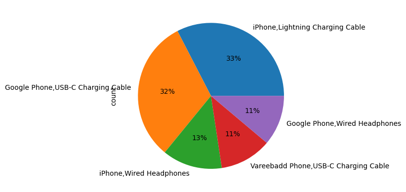

```python
no_dup_df['grouped_products'].value_counts()[0:5].plot.pie(autopct = '%1.0f%%')
```

```python
##ie as soon as any Person will bought Iphone , we can recommend him charging cable , wired headphones
##ie as soon as any Person will bought Google phone , we can recommend him USB-c charging cable
##This is a very important insight if someone is building recommendation system ..
```